# I am a Resampler

```r
library(ggplot2)
```

### Getting Started

Before we push too hard on this topic, lets review some r functions that we will need for doing this work. Let’s read under Resampling Functions

To push us on the idea behind resampling techniques let’s simulate data from a known population. Let’s try the normal distribution with $\mu=4$ and $sd=8$.

- Here is what the normal distribution would look like.

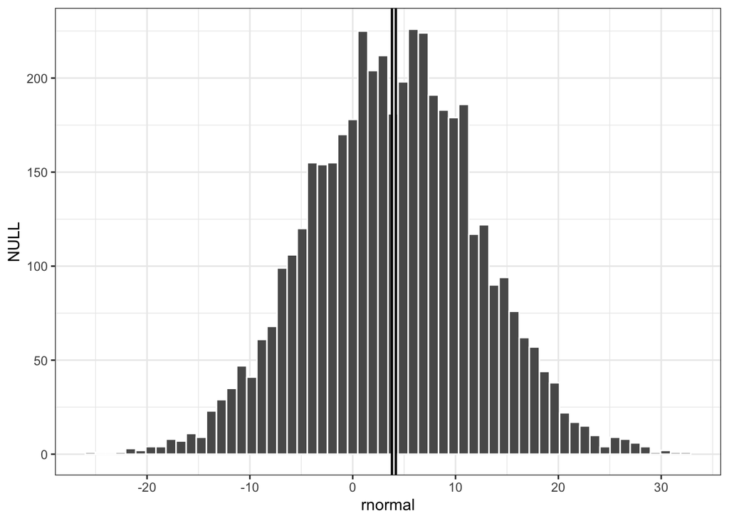

```r
rnormal = rnorm(4500,4,8)

# Good depiction of the true distribution
qplot(x=rnormal,colour=I("white"),bins=60)+
  geom_vline(xintercept=mean(rnormal),size=2)+geom_vline(xintercept=mean(rnormal),colour="white")+
  theme_bw()
```

- Now we are going to take a sample of $n=50$.

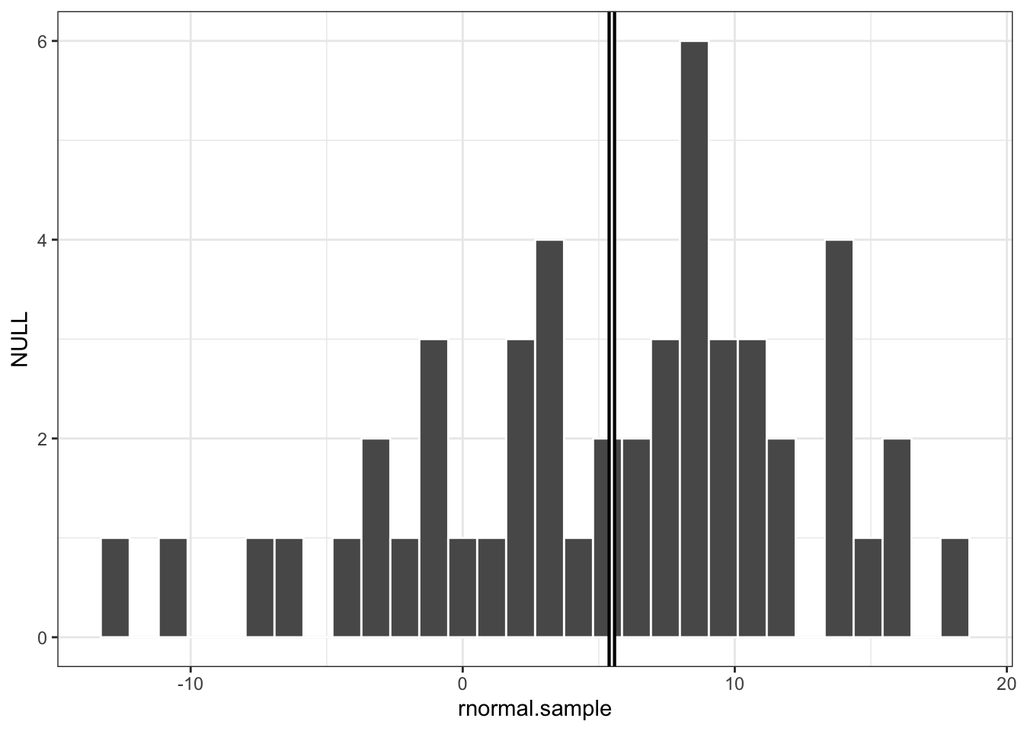

```r
rnormal.sample = rnorm(50,4,8)
qplot(x=rnormal.sample,colour=I("white"),bins=30)+
  geom_vline(xintercept=mean(rnormal.sample),size=2)+
  geom_vline(xintercept=mean(rnormal.sample),colour="white")+
  theme_bw()
```

- So we can get our confidence interval on the sampling distribution of means based on 50 observations using the `t.test()` function.

```r
tresults.norm = t.test(rnormal.sample,conf.int=TRUE,mu=4)
tresults.norm$conf.int
```

```
## [1] 3.455247 7.506210
## attr(,"conf.level")
## [1] 0.95
```

- Discuss with your table what the the following plot represents?

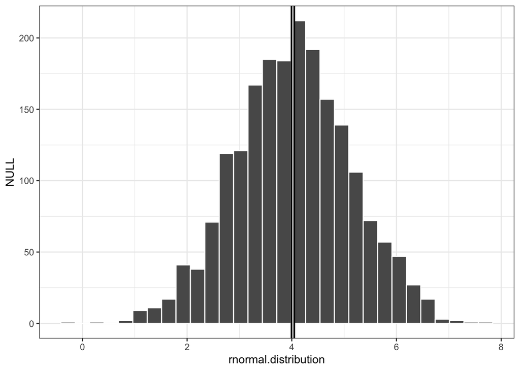

```r
rnormal.distribution = replicate(2000,mean(rnorm(50,4,8)))
qplot(x=rnormal.distribution,colour=I("white"))+
 geom_vline(xintercept=mean(rnormal.distribution),size=2)+
 geom_vline(xintercept=mean(rnormal.distribution),colour="white")+
 theme_bw()
```

### The Bootstrap Idea

**Now we can introduce the bootstrap concept.**

- Take some time with your table to explain what the next two lines of code are doing.
- How is the below plot similar to the previous plot?

```r
bsvalue.norm = replicate(2000,mean(sample(rnormal.sample,50,replace=TRUE)))
quantile(bsvalue.norm,c(.025,.975))
```

```
##     2.5%    97.5%
## 3.516637 7.406639
```

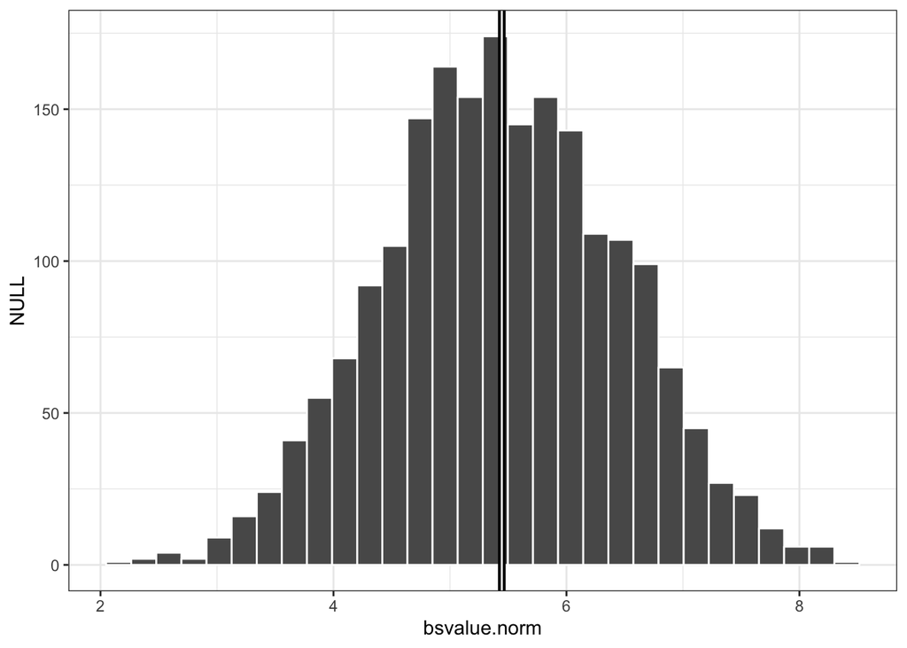

```r
qplot(x=bsvalue.norm,colour=I("white"))+
  geom_vline(xintercept=mean(bsvalue.norm),size=2)+
  geom_vline(xintercept=mean(bsvalue.norm),colour="white")+
  theme_bw()
```

The above code chunk is called the bootstrap percentile interval. In the code chunk below we exemplify the bootstrap t interval.

- Work with your table to write down in “pseudo code” on the board what the below code chunk is doing.
- Discuss with your table what differences you see in the below code compared to the above percentile interval.

```r
bsvalue.t.norm = replicate(20000,{

  bsample = sample(rnormal.sample,50,replace=TRUE)
  bmean = mean(bsample)
  smean = mean(rnormal.sample)
  bse = sd(bsample)/sqrt(50)
  (bmean - smean)/bse

})

c("lower"=mean(rnormal.sample)-quantile(bsvalue.t.norm,.975),"upper"=mean(rnormal.sample)-quantile(bsvalue.t.norm,.025))
```

```
## lower.97.5%  upper.2.5%
##    3.363743    7.394216
```

OK. Now we have three different confidence interval methods. Let’s compare them to the known true confidence interval.

$$\bar{x} \pm t_{1-\alpha/2} \times \frac{\sigma}{\sqrt{50}}$$
* Notice that they are all slightly different. Let’s discuss why this is so.

```r
as.numeric(tresults.norm$conf.int)
```

```
## [1] 3.455247 7.506210
```

```r
quantile(bsvalue.norm,c(.025,.975))
```

```
##     2.5%    97.5%
## 3.516637 7.406639
```

```r
c("lower"=mean(rnormal.sample)-quantile(bsvalue.t.norm,.975),"upper"=mean(rnormal.sample)-quantile(bsvalue.t.norm,.025))
```

```
## lower.97.5%  upper.2.5%
##    3.363743    7.394216
```

```r
mean(rnormal.sample)-qt(.975,49)*8/sqrt(50);mean(rnormal.sample)+qt(.975,49)*8/sqrt(50)
```

```
## [1] 3.207154
```

```
## [1] 7.754304
```

For the next part we need to introduce the concept of `coverage`. Simply stated, it is the number of times our convidence interval encompasses the true mean. If we designed a 95% confidence interval we would like the interval to “cover” the mean 95% of the time.

```r
normcov = replicate(200,{
  # sample
  rnormal.sample = rnorm(50,4,8)

  #Normal t
  tresults.norm = t.test(rnormal.sample,conf.int=TRUE,mu=4)
  nt = as.numeric(tresults.norm$conf.int)



  # bootstrap percentile
  bsvalue.norm = replicate(2000,mean(sample(rnormal.sample,50,replace=TRUE)))
  bsp = quantile(bsvalue.norm,c(.025,.975))

  # bootstrap t
  bsvalue.t.norm = replicate(20000,{

  bsample = sample(rnormal.sample,50,replace=TRUE)
  bmean = mean(bsample)
  smean = mean(rnormal.sample)
  bse = sd(bsample)/sqrt(50)
  (bmean - smean)/bse
  })
  bst = c("lower"=mean(rnormal.sample)-quantile(bsvalue.t.norm,.975),"upper"=mean(rnormal.sample)-quantile(bsvalue.t.norm,.025))

  nt.contained = nt[1]<4 & nt[2]>4
  bst.contained = bst[1]<4 & bst[2]>4
  bsp.contained = bsp[1]<4 & bst[2]>4

  data.frame(nt=nt.contained,bst=bst.contained,bsp=bsp.contained)

},simplify=F)


apply(do.call("rbind",normcov),2,mean)
#    nt   bst   bsp
# 0.960 0.935 0.940
# sampling error is 0.015.
```

### The Boostrap Purpose

The above process gave us comparable results. However, why would we go through the process of all the simulations to get the same results a simple t calculation could give us?

The following example exemplifies why the bootstrap is so powerful. Look at the following distribution that is heavily right skewed. It is what we would also describe as a heavy-tailed distribution.

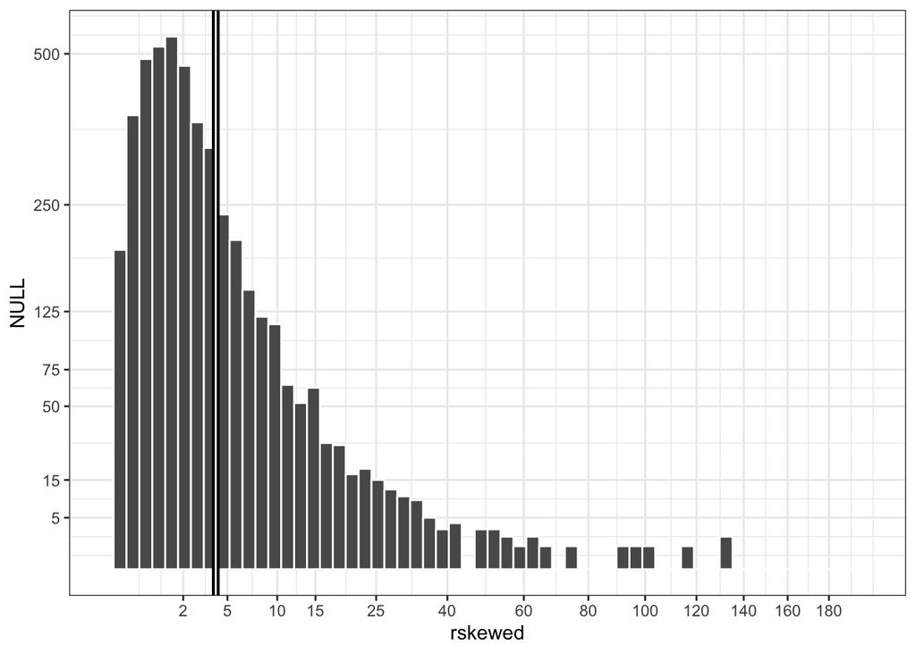

```r
#install.packages("rmutil")
library(rmutil)
library(resample)
dispersion = 2.5

rskewed = rpareto(4500,4,dispersion)

# Good depiction of the true distribution
qplot(x=rskewed,colour=I("white"),bins=60)+
  scale_x_continuous(trans="sqrt",breaks=c(2,5,10,15,25,40,60,80,100,120,140,160,180),limits=c(0,200))+
  scale_y_continuous(trans="sqrt",breaks=c(5,15,50,75,125,250,500,750))+
  geom_vline(xintercept=mean(rskewed),size=2)+geom_vline(xintercept=mean(rskewed),colour="white")+
  theme_bw()
```

- Before running the plots, look at the first few lines of code and discuss with your group what the sampling distribution of each line of code might look like.
- Now make the plots with the additional lines of code in this chunk.
- What do you think about using the t-interval based on normality?

```r
#install.packages("rmutil")
library(rmutil)
rskewed.distribution = replicate(10000,mean(rpareto(50,4,dispersion)))
rskewed.distribution.500 = replicate(2000,mean(rpareto(5000,4,dispersion)))


qplot(x=rskewed.distribution,colour=I("white"))+
  scale_x_continuous(trans="sqrt",breaks=c(2,5,10,15,25,40,60,80,100,120,140,160,180),limits=c(0,25))+
  scale_y_continuous(trans="sqrt",breaks=c(5,15,50,75,125,250,500,750))+
  geom_vline(xintercept=mean(rskewed.distribution),size=2)+geom_vline(xintercept=mean(rskewed.distribution),colour="white")+
  theme_bw()

# what do you notice about our sampling distribution?

# Well what if we have 5000 observation to calculate our mean. Surely the CLT must kick in.

qplot(x=rskewed.distribution.500,colour=I("white"))+
  scale_x_continuous(trans="sqrt",breaks=c(2,5,10,15,25,40,60,80,100,120,140,160,180),limits=c(3,5))+
  scale_y_continuous(trans="sqrt",breaks=c(5,15,50,75,125,250,500,750))+
  geom_vline(xintercept=mean(rskewed.distribution.500),size=2)+geom_vline(xintercept=mean(rskewed.distribution.500),colour="white")+
  theme_bw()
```

[output not shown]

```r
rskewed.sample = rpareto(50,4,dispersion)

qplot(x=rskewed.sample,colour=I("white"),bins=60)+
  scale_x_continuous(trans="sqrt",breaks=c(2,5,10,15,25,40,60,80,100,120,140,160,180),limits=c(0,200))+
  scale_y_continuous(trans="sqrt",breaks=c(5,15,50,75,125,250,500,750))+
  geom_vline(xintercept=mean(rskewed.sample),size=2)+geom_vline(xintercept=mean(rskewed.sample),colour="white")+
  theme_bw()

## Now if we use our nieve interpretation of the CLT then 50 should kick in the normal distribution. Thus we can get a 95% confidence interval using the t.
##

tresults = t.test(rskewed.sample,conf.int=TRUE,mu=4)

# The bootstrap runs
se = function(x) sd(x)/sqrt(length(x))
bsvalue = bootstrap(rskewed.sample,c(mean=mean(rskewed.sample),se(rskewed.sample)))


# The percentile bootstrap method.

qplot(data=data.frame(bsvalue$replicates),x=mean,colour=I("white"))+
  scale_x_continuous(trans="sqrt",breaks=c(2,5,10,15,25,40,60,80,100,120,140,160,180),limits=c(0,25))+
  scale_y_continuous(trans="sqrt",breaks=c(5,15,50,75,125,250,500,750))+
  geom_vline(aes(xintercept=mean(mean)),size=2)+geom_vline(aes(xintercept=mean(mean)),colour="white")+
  theme_bw()


# Once again we can compare our results. However, this time we will use the resampling package.
CI.percentile(bsvalue,expand=FALSE)
CI.percentile(bsvalue,expand=TRUE)
CI.bootstrapT(bsvalue)
CI.bca(bsvalue)
as.numeric(tresults$conf.int)
```

[output not shown]

Let’s check out coverage with this heavy-tailed data.

```r
library(rmutil)

skewcov = replicate(2000,{
  # sample
  rskewed.sample = rpareto(50,4,2.5)

  #Normal t
  tresults.norm = t.test(rskewed.sample,conf.int=TRUE,mu=4)
  nt = as.numeric(tresults.norm$conf.int)



  # bootstrap percentile
  bsvalue.norm = replicate(2000,mean(sample(rskewed.sample,50,replace=TRUE)))
  bsp = quantile(bsvalue.norm,c(.025,.975))

  # bootstrap t
  bsvalue.t.norm = replicate(20000,{

  bsample = sample(rskewed.sample,50,replace=TRUE)
  bmean = mean(bsample)
  smean = mean(rskewed.sample)
  bse = sd(bsample)/sqrt(50)
  (bmean - smean)/bse
  })
  se = function(x) sd(x)/sqrt(length(x))
  bst = c("lower"=mean(rskewed.sample)-quantile(bsvalue.t.norm,.975)*se(rskewed.sample),"upper"=mean(rskewed.sample)-quantile(bsvalue.t.norm,.025)*se(rskewed.sample))


  bsvalue = bootstrap(rskewed.sample,c(mean=mean(rskewed.sample),se(rskewed.sample)))
  rpf=CI.percentile(bsvalue,expand=FALSE)[1,]
  rpt=CI.percentile(bsvalue,expand=TRUE)[1,]
  rbt=CI.bootstrapT(bsvalue)[1,]

  nt.contained = nt[1]<4 & nt[2]>4
  bst.contained = bst[1]<4 & bst[2]>4
  bsp.contained = bsp[1]<4 & bsp[2]>4
  rpf.contained = rpf[1]<4 & rpf[2]>4
  rpt.contained = rpt[1]<4 & rpt[2]>4
  rbt.contained = rbt[1]<4 & rbt[2]>4

  data.frame(nt=nt.contained,bst=bst.contained,bsp=bsp.contained,
             rpf=rpf.contained,rpt=rpt.contained,rbt=rbt.contained)

},simplify=F)


apply(do.call("rbind",skewcov),2,mean)
#all with dispersion of 2.5
#0.0069 is the SE of the coverage
#   nt   bst   bsp   rpf   rpt   rbt
#0.848 0.916 0.842 0.850 0.856 0.914
```